# P8106_HW3_sp4436

Sukhman Parhar

2026-04-01

```r
knitr::opts_chunk$set(echo = TRUE)

library(tidyverse)
library(ISLR)
library(glmnet)
library(caret)
library(tidymodels)
library(corrplot)
library(ggplot2)
library(plotmo)
library(ggrepel)
library(pls)
library(pdp)
library(earth)
library(splines)
library(mgcv)
library(patchwork)
library(readr)
library(pROC)
library(vip)
library(discrim)
library(MASS)
library(klaR)
```

#### Clean the data

```r
# Load in the data
auto <- read_csv("auto.csv") %>%
  na.omit() %>%
  as.data.frame()

# Remove cars with 3 cylinders
auto <- auto[auto$cylinders != 3, ]

# Convert Outcome (mpg_cat) to factor
auto$mpg_cat <- factor(auto$mpg_cat)

# Convert Origin to factor
auto$origin <- as.factor(auto$origin)

#summary(auto)
```

#### Split the data

```r
set.seed(2)

split <- initial_split(auto, prop = 0.7)

train_data <- training(split)
test_data  <- testing(split)

# set up cross validation control
ctrl <- trainControl(method = "cv", number = 10,
                     summaryFunction = twoClassSummary,
                     classProbs = TRUE)
```

#### Question 1: Perform logistic regression analysis. Are there redundant predictors in your model? If so, identify them. If there are none, please provide an explanation.

```r
# Fit tuning GLM
glm.fit <- glm(mpg_cat ~ ., data = train_data, family = binomial)
summary(glm.fit)
```

```
##
## Call:
## glm(formula = mpg_cat ~ ., family = binomial, data = train_data)
##
## Coefficients:
##               Estimate Std. Error z value Pr(>|z|)
## (Intercept)  26.245325   8.530634   3.077  0.00209 **
## cylinders     0.897590   0.552539   1.624  0.10427
## displacement -0.023045   0.015425  -1.494  0.13517
## horsepower    0.014403   0.029716   0.485  0.62789
## weight        0.005672   0.001503   3.775  0.00016 ***
## acceleration -0.124973   0.186073  -0.672  0.50182
## year         -0.547819   0.112239  -4.881 1.06e-06 ***
## origin2      -1.699338   0.885517  -1.919  0.05498 .
## origin3      -0.982624   0.877644  -1.120  0.26288
## ---
## Signif. codes:  0 '***' 0.001 '**' 0.01 '*' 0.05 '.' 0.1 ' ' 1
##
## (Dispersion parameter for binomial family taken to be 1)
##
##     Null deviance: 375.653  on 270  degrees of freedom
## Residual deviance:  97.184  on 262  degrees of freedom
## AIC: 115.18
##
## Number of Fisher Scoring iterations: 8
```

```r
set.seed(2)

model.glm <- train(mpg_cat ~ .,
                   data = train_data,
                   method = "glm",
                   metric = "ROC",
                   trControl = ctrl)
# Summary
summary(model.glm)
```

```
##
## Call:
## NULL
##
## Coefficients:
##               Estimate Std. Error z value Pr(>|z|)
## (Intercept)  26.245325   8.530634   3.077  0.00209 **
## cylinders     0.897590   0.552539   1.624  0.10427
## displacement -0.023045   0.015425  -1.494  0.13517
## horsepower    0.014403   0.029716   0.485  0.62789
## weight        0.005672   0.001503   3.775  0.00016 ***
## acceleration -0.124973   0.186073  -0.672  0.50182
## year         -0.547819   0.112239  -4.881 1.06e-06 ***
## origin2      -1.699338   0.885517  -1.919  0.05498 .
## origin3      -0.982624   0.877644  -1.120  0.26288
## ---
## Signif. codes:  0 '***' 0.001 '**' 0.01 '*' 0.05 '.' 0.1 ' ' 1
##
## (Dispersion parameter for binomial family taken to be 1)
##
##     Null deviance: 375.653  on 270  degrees of freedom
## Residual deviance:  97.184  on 262  degrees of freedom
## AIC: 115.18
##
## Number of Fisher Scoring iterations: 8
```

```r
print(model.glm)
```

```
## Generalized Linear Model
##
## 271 samples
##   7 predictor
##   2 classes: 'high', 'low'
##
## No pre-processing
## Resampling: Cross-Validated (10 fold)
## Summary of sample sizes: 244, 245, 243, 244, 244, 244, ...
## Resampling results:
##
##   ROC        Sens      Spec
##   0.9705048  0.928022  0.9104396
```

```r
coef(model.glm$finalModel)
```

```
##  (Intercept)    cylinders displacement   horsepower       weight acceleration
## 26.245325015  0.897590111 -0.023044718  0.014403449  0.005672252 -0.124972940
##         year      origin2      origin3
## -0.547819306 -1.699338276 -0.982624382
```

#### Fit a penalized logistic regression model

```r
glmnGrid = expand.grid(.alpha = seq(0, 1, length = 21),
                      .lambda = exp(seq(-8, -1, length = 50)))

set.seed(2)

model.pen.logr = train(mpg_cat ~ .,
                   data = train_data,
                       method = "glmnet",
                       tuneGrid = glmnGrid,
                       metric = "ROC",
                       trControl = ctrl)

model.pen.logr$bestTune
```

```
##      alpha     lambda
## 1031     1 0.02437284
```

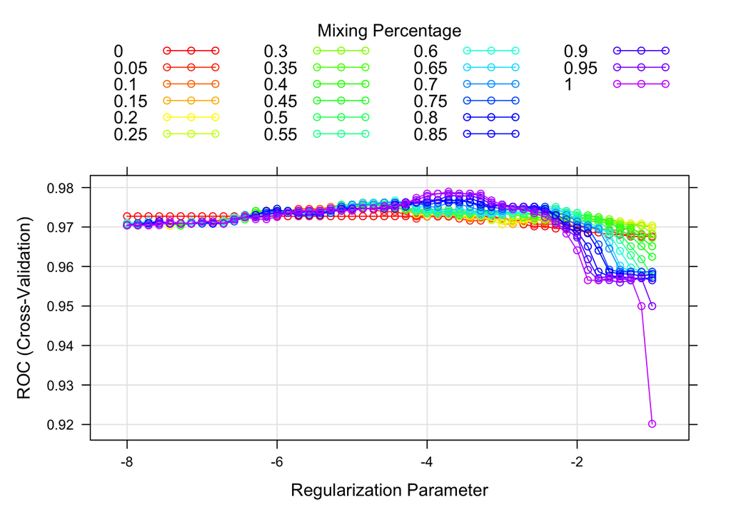

```r
myCol = rainbow(25)

myPar = list(superpose.symbol = list(col = myCol),
             superpose.line = list(col = myCol))

plot(model.pen.logr, par.settings = myPar, xTrans = function(x) log(x))
```

```r
coef(model.pen.logr$finalModel, model.pen.logr$bestTune$lambda)
```

```
## 9 x 1 sparse Matrix of class "dgCMatrix"
##              s=0.02437284
## (Intercept)  10.045051572
## cylinders     0.488128367
## displacement  .
## horsepower    .
## weight        0.002256364
## acceleration  .
## year         -0.250092178
## origin2       .
## origin3       .
```

Yes there are redundant predictors within this model. Only weight, year, and cylinders are not redundant, while displacement, horsepower, acceleration, and if the car is European origin or Japanese origin are redundant. Predictors with coefficients shrunk to zero by LASSO are redundant in the presence of the correlated predictors (weight and cylinders)

#### Question 2: Train a multivariate adaptive regression spline (MARS) model. Does the MARS model improve prediction performance compared to logistic regression?

```r
# MARS
set.seed(2)

mars_grid <- expand.grid(degree = 1:3,
                         nprune = 2:20)

model.mars <- train(mpg_cat ~ .,
                   data = train_data,
                    method = "earth",
                    tuneGrid = mars_grid,
                    metric = "ROC",
                    trControl = ctrl)

# Best tuning parameters for MARS
model.mars$bestTune
```

```
##    nprune degree
## 27      9      2
```

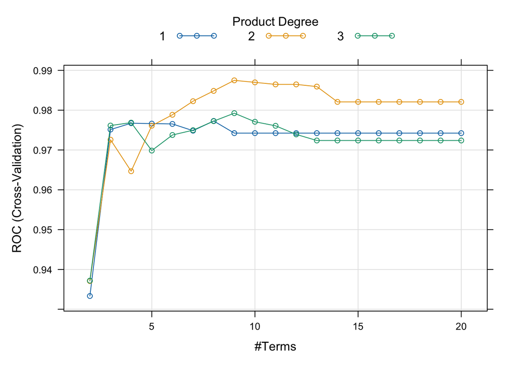

```r
# Plot CV performance for MARS
plot(model.mars)
```

```r
# compare cross-validation performance
res <- resamples(list(Logistic = model.glm,
                      GLMNET = model.pen.logr,
                      MARS = model.mars))

summary(res)
```

```
##
## Call:
## summary.resamples(object = res)
##
## Models: Logistic, GLMNET, MARS
## Number of resamples: 10
##
## ROC
##               Min.   1st Qu.    Median      Mean   3rd Qu. Max. NA's
## Logistic 0.8901099 0.9466852 0.9913356 0.9705048 0.9986264    1    0
## GLMNET   0.9285714 0.9672971 0.9883770 0.9789428 0.9986264    1    0
## MARS     0.9438776 0.9839391 0.9947017 0.9874955 1.0000000    1    0
##
## Sens
##               Min.   1st Qu.    Median      Mean   3rd Qu. Max. NA's
## Logistic 0.7857143 0.9244505 0.9285714 0.9280220 0.9821429    1    0
## GLMNET   0.9285714 0.9285714 1.0000000 0.9714286 1.0000000    1    0
## MARS     0.7857143 0.9244505 1.0000000 0.9494505 1.0000000    1    0
##
## Spec
##               Min.   1st Qu.    Median      Mean   3rd Qu. Max. NA's
## Logistic 0.7692308 0.9230769 0.9230769 0.9104396 0.9285714    1    0
## GLMNET   0.7692308 0.8489011 0.8901099 0.8884615 0.9230769    1    0
## MARS     0.9230769 0.9230769 0.9258242 0.9472527 0.9821429    1    0
```

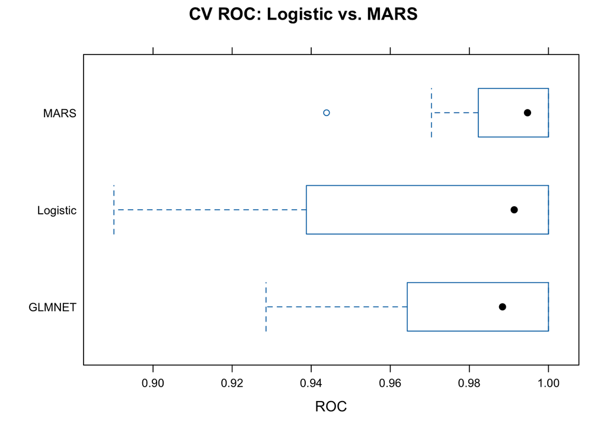

```r
bwplot(res, metric = "ROC", main = "CV ROC: Logistic vs. MARS")
```

#### Question 3: Perform linear discriminant analysis using the training data. Plot the linear discriminant(s).

```r
# Fit LDA model
lda.fit <- lda(mpg_cat ~ ., data = train_data)

# View model
lda.fit
```

```
## Call:
## lda(mpg_cat ~ ., data = train_data)
##
## Prior probabilities of groups:
##      high       low
## 0.5055351 0.4944649
##
## Group means:
##      cylinders displacement horsepower   weight acceleration     year
## high  4.182482     115.7007   78.69343 2315.234     16.45766 77.64964
## low   6.820896     280.0000  132.73134 3673.910     14.35896 74.10448
##         origin2    origin3
## high 0.27737226 0.35036496
## low  0.08208955 0.03731343
##
## Coefficients of linear discriminants:
##                       LD1
## cylinders     0.587431117
## displacement -0.002472710
## horsepower   -0.012291415
## weight        0.001228329
## acceleration -0.018631844
## year         -0.149519095
## origin2      -0.322288849
## origin3      -0.396180163
```

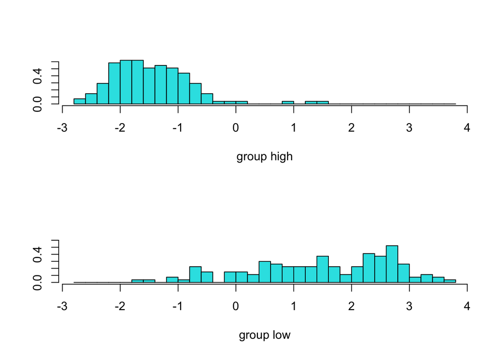

```r
plot(lda.fit)
```

```r
lda.fit$scaling
```

```
##                       LD1
## cylinders     0.587431117
## displacement -0.002472710
## horsepower   -0.012291415
## weight        0.001228329
## acceleration -0.018631844
## year         -0.149519095
## origin2      -0.322288849
## origin3      -0.396180163
```

```r
set.seed(2)

model.lda <- train(mpg_cat ~ .,
                   data = train_data,
                   method = "lda",
                   metric = "ROC",
                   trControl = ctrl)
```

#### Question 4: Which model will you choose to predict the response variable? Plot its ROC curve and report the AUC.

```r
set.seed(2)

# Compare all models
resd <- resamples(list(
  Logistic = model.glm,
  MARS = model.mars,
  GLMNET = model.pen.logr,
  LDA = model.lda
))

summary(resd)
```

```
##
## Call:
## summary.resamples(object = resd)
##
## Models: Logistic, MARS, GLMNET, LDA
## Number of resamples: 10
##
## ROC
##               Min.   1st Qu.    Median      Mean   3rd Qu. Max. NA's
## Logistic 0.8901099 0.9466852 0.9913356 0.9705048 0.9986264    1    0
## MARS     0.9438776 0.9839391 0.9947017 0.9874955 1.0000000    1    0
## GLMNET   0.9285714 0.9672971 0.9883770 0.9789428 0.9986264    1    0
## LDA      0.8775510 0.9482249 0.9766484 0.9631747 0.9934262    1    0
##
## Sens
##               Min.   1st Qu.    Median      Mean   3rd Qu. Max. NA's
## Logistic 0.7857143 0.9244505 0.9285714 0.9280220 0.9821429    1    0
## MARS     0.7857143 0.9244505 1.0000000 0.9494505 1.0000000    1    0
## GLMNET   0.9285714 0.9285714 1.0000000 0.9714286 1.0000000    1    0
## LDA      0.8571429 0.9285714 1.0000000 0.9642857 1.0000000    1    0
##
## Spec
##               Min.   1st Qu.    Median      Mean   3rd Qu. Max. NA's
## Logistic 0.7692308 0.9230769 0.9230769 0.9104396 0.9285714    1    0
## MARS     0.9230769 0.9230769 0.9258242 0.9472527 0.9821429    1    0
## GLMNET   0.7692308 0.8489011 0.8901099 0.8884615 0.9230769    1    0
## LDA      0.6923077 0.7857143 0.8461538 0.8445055 0.9230769    1    0
```

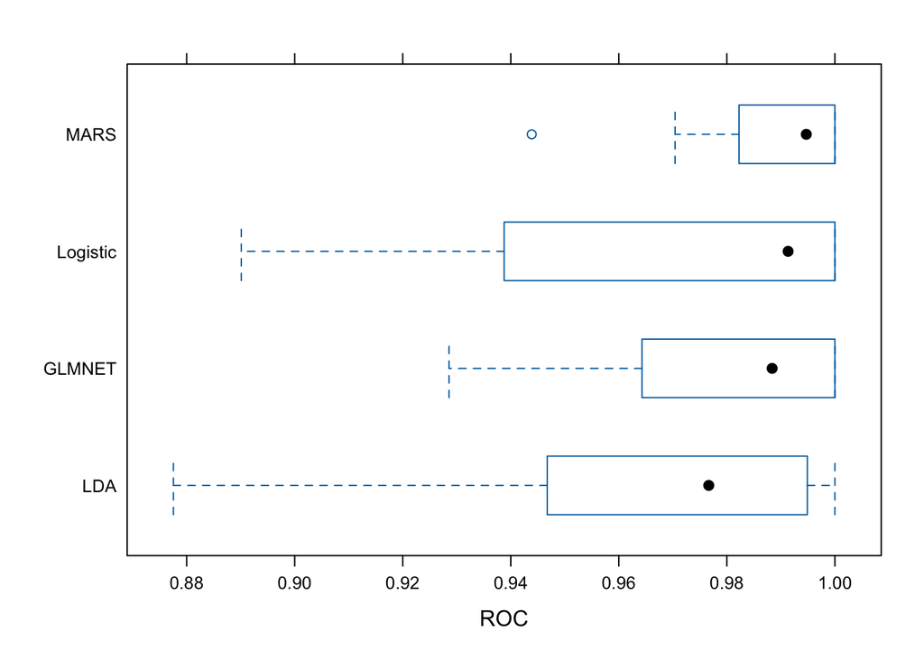

```r
bwplot(resd, metric = "ROC")
```

#### MARS performed the best

```r
# Predict probabilities (MARS)
mars.probs <- predict(model.mars,
                      newdata = test_data,
                      type = "prob")[,2]

# ROC curve
roc.mars <- roc(test_data$mpg_cat, mars.probs)
# AUC
auc(roc.mars)
```

```
## Area under the curve: 0.9795
```

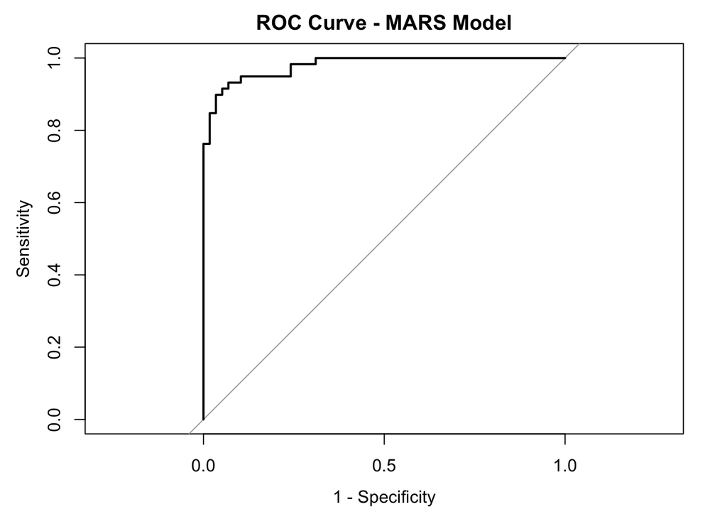

```r
# Plot ROC
plot(roc.mars, legacy.axes = TRUE,
     main = "ROC Curve - MARS Model")
```

Area under the curve: 0.9795

#### Question 5: Select a probability threshold to classify observations and compute the confusion matrix for the final model you choose. Briefly interpret what the confusion matrix indicates about your model’s performance

```r
# Predict probabilities High
test.probs <- predict(model.mars, newdata = test_data, type = "prob")

test.pred.prob <- test.probs[, "high"]

# Convert
test.pred <- rep("low", length(test.pred.prob))
test.pred[test.pred.prob > 0.5] <- "high"

# confusion matrix
confusionMatrix(data = as.factor(test.pred),
                reference = test_data$mpg_cat,
                positive = "high")
```

```
## Confusion Matrix and Statistics
##
##           Reference
## Prediction high low
##       high   55   5
##       low     3  54
##
##                Accuracy : 0.9316
##                  95% CI : (0.8697, 0.97)
##     No Information Rate : 0.5043
##     P-Value [Acc > NIR] : <2e-16
##
##                   Kappa : 0.8633
##
##  Mcnemar's Test P-Value : 0.7237
##
##             Sensitivity : 0.9483
##             Specificity : 0.9153
##          Pos Pred Value : 0.9167
##          Neg Pred Value : 0.9474
##              Prevalence : 0.4957
##          Detection Rate : 0.4701
##    Detection Prevalence : 0.5128
##       Balanced Accuracy : 0.9318
##
##        'Positive' Class : high
##
```

A threshold of 0.5 was selected because choosing 0.5 assumes that the costs associated with False Positives (misclassifying a low-efficiency car as high) and False Negatives (failing to identify a high-efficiency car) are equal.

Mars has an overall Accuracy of 0.9316. The Sensitivity of 0.9483 means it can identify true high-mileage vehicles, while the Specificity of 0.9153 shows it can identify low-mileage vehicles. The no information rate of 0.5043 shows that high accuracy is not due to a high probability of being low or high MPG in the data set. This is reinforced by the P-value [accuracy > no information rate], which is extremely close to 0, indicating that the classifier works very well. We also see a kappa calue of 0.8633 which is close to one meaning this ia a good classifier. These show that this model performs well.